# Vignette 1: Single trait analysis with homogeneous GxE

### Preface

This vignette illustrates basic features of the package using a potato breeding dataset of 943 genotypes (i.e., clones), with phenotype data from six years at one location. It is an updated version of the dataset published by [Endelman et al. (2018)](https://doi.org/10.1534/genetics.118.300685). This vignette covers single trait analysis, under the assumption that all environments have the same genetic correlation (i.e., compound symmetry). The analysis of multiple locations with different correlations are covered in [Vignette 2](https://jendelman.github.io/StageWise/Vignette2.html), and the analysis of correlated traits is covered in [Vignette 3](https://jendelman.github.io/StageWise/Vignette3.html).

There are five main functions in the package:

- `read_geno`
- `Stage1`
- `Stage2`
- `blup_prep`
- `blup`

The package depends on ASReml-R (version 4.1.0.148 or later), which requires a license from [VSN International](https://www.vsni.co.uk/software/asreml-r).

### Stage 1

In Stage 1, the data for each environment are analyzed independently, which allows for the selection of different models tailored to different experimental designs and patterns of spatial variation. The `Stage1` function in the package offers a number of commonly used analysis methods, but it also possible to use other software for Stage 1. For a linear model with only fixed and i.i.d. random effects, the argument `solver="asreml"` triggers the use of ASReml-R for variance component estimation. Another option is `solver="spats"`, which triggers the use of R package [SpATS](https://cran.r-project.org/web/packages/SpATS/index.html) to fit a 2D spline (in addition to fixed or i.i.d. effects). Regardless of which solver is used, at least some of the individuals should be replicated (which includes augmented designs with repeated checks). If you have no replication within environment, skip Stage 1 and go to Stage 2.

There are two required columns in the CSV file of phenotype data used in `Stage1`: “id” contains the individual identifier and is matched against the information from the genotype input file; and “env” is the name of the environment, which is typically a location x year combination. (This vignette illustrates the analysis of multiple years from one location, or when multiple locations are similar enough that the genotype x location effect can be neglected. For the analysis of correlated locations, consult [Vignette 2](https://jendelman.github.io/StageWise/Vignette2.html) after you complete this vignette.) The other columns in the input file contain traits, cofactors, or covariates.

The phenotypes for this tutorial are based on six years (2015-2020) of variety trials at the Hancock Research Station of the University of Wisconsin. Data for the first five years are in the file “pheno1a”, which includes a column with an incomplete blocking factor. The 2020 data are provided in the file “pheno1b” and consists of two partially replicated trials (preliminary and advanced), with row and range information to illustrate spatial analysis.

- total yield (Mg per ha)
- vine maturity (1=early to 9=late)
- fry color, measured in units of Hunter Lightness (L) after 6 months of storage

The data files also contain the stand count for each plot (out of 15 total plants), which is included as a covariate in the Stage 1 model.

```r
pheno1a.file <- system.file("vignette_data", "pheno1a.csv", package = "StageWise")
pheno1a <- read.csv(pheno1a.file)
kable(head(pheno1a))
```

| env | id | block | total.yield | vine.maturity | fry.color | stand.count |
| --- | --- | --- | --- | --- | --- | --- |
| Hancock15 | A00188-3C | 2 | 68.1 | 8 | 47.8 | 15 |
| Hancock15 | A00188-3C | 3 | 71.2 | 8 | 47.3 | 15 |
| Hancock15 | A01143-3C | 2 | 109.2 | 8 | 48.4 | 15 |
| Hancock15 | A01143-3C | 3 | 105.3 | 9 | 51.9 | 15 |
| Hancock15 | A09037-6C | 1 | 70.3 | 5 | 53.9 | 15 |
| Hancock15 | AAF07847-2 | 1 | 77.6 | 8 | 49.0 | 15 |

```r
pheno1b.file <- system.file("vignette_data", "pheno1b.csv", package = "StageWise")
pheno1b <- read.csv(pheno1b.file)
kable(head(pheno1b))
```

| env | expt | row | range | id | total.yield | vine.maturity | fry.color | stand.count |
| --- | --- | --- | --- | --- | --- | --- | --- | --- |
| Hancock20 | prelim | 1 | 1 | W17037-24 | 44.7 | 3 | 58.0 | 15 |
| Hancock20 | prelim | 1 | 2 | W17062-11 | 38.8 | 4 | 61.5 | 13 |
| Hancock20 | prelim | 1 | 3 | W17064-7 | 36.8 | 2 | 61.2 | 15 |
| Hancock20 | prelim | 1 | 4 | W17039-15 | 45.4 | 3 | 59.6 | 15 |
| Hancock20 | prelim | 1 | 5 | W17039-30 | 47.1 | 5 | 61.9 | 15 |
| Hancock20 | prelim | 1 | 6 | W17039-7 | 64.8 | 3 | 61.4 | 15 |

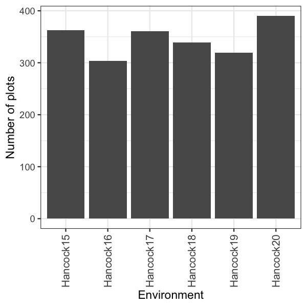

```r
tmp <- merge(pheno1a[,c("env","id")],pheno1b[,c("env","id")],all=T)
library(ggplot2)
ggplot(data=tmp,aes(x=env)) + geom_bar() +
  ylab("Number of plots") + xlab("Environment") + theme_bw() +
  theme(axis.text.x=element_text(angle=90,vjust=0.5,size=10))
```

As is typical of breeding trials, the majority of clones were tested in one year and then dropped, but there is sufficient replication across years to estimate genotype x env interactions.

A data frame with variables “name”, “fixed”, and “factor” is used to specify which columns of the input file should be included as covariates or cofactors, and whether the effects are fixed or random. We begin with analysis of the 2015-2019 data, using “block” and “stand.count” as cofactor and covariate, respectively:

```r
effects <- data.frame(name=c("block","stand.count"),
                      fixed=c(FALSE,TRUE),
                      factor=c(TRUE,FALSE))
effects
```

```
##          name fixed factor
## 1       block FALSE   TRUE
## 2 stand.count  TRUE  FALSE
```

```r
library(StageWise)
ans1a <- Stage1(filename=pheno1a.file,traits="total.yield",
                effects=effects,solver="asreml")
```

```
## Online License checked out Mon Sep  1 15:34:02 2025
```

The `Stage1` function returns a list with several results. List element “blue” is a data frame of the individual BLUEs per environment. Element “fit” contains the AIC and broad-sense heritability (H2), with H2 reported per plot (i.e., Vg/(Vg+Ve)) and entry-mean (i.e., generalized H2; Oakey et al. 2006).

```r
head(ans1a$blues)
```

```
##         env          id      BLUE
## 1 Hancock15   A00188-3C  66.81187
## 2 Hancock15   A01143-3C 104.41187
## 3 Hancock15   A09037-6C  76.55071
## 4 Hancock15  AAF07847-2  83.85071
## 5 Hancock15  AC01144-1W  70.81187
## 6 Hancock15 Accumulator  83.36187
```

```r
ans1a$fit
```

```
##            env H2.plot H2.entry   AIC
## 1    Hancock15   0.711    0.736 531.6
## 364  Hancock16   0.721    0.758 436.7
## 668  Hancock17   0.702    0.712 284.0
## 1029 Hancock18   0.832    0.845 246.4
## 1368 Hancock19   0.758    0.785 340.8
```

To check for outliers and normality of the residuals, use the plots contained in list element “resid”:

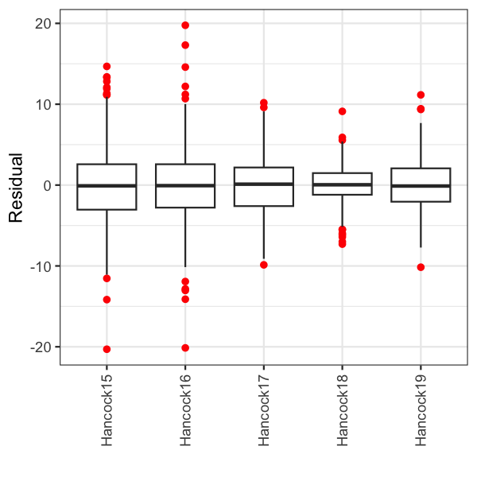

```r
ans1a$resid$boxplot
```

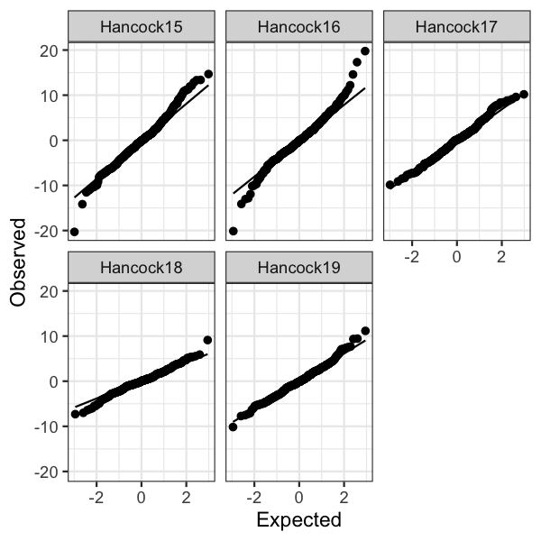

```r
ans1a$resid$qqplot
```

The reserved word “expt” in the input file, which is short for “experiment”, directs Stage1 to fit separate models for each experiment within an environment. Then, in a second step, a single BLUE for each genotype in that environment is estimated, including the full var-cov matrix. Compared to simply use “expt” as a factor in a single step, this two-step procedure within Stage1 allows for separate spatial models.

The 2020 data file contains two experiments: a preliminary and advanced trial. Here is a comparison of using random row and range effects vs. a 2D spline, which requires the additional argument `spline` to indicate the names of the variables in the input file with the x and y coordinates.

```r
effects <- data.frame(name=c("row","range","stand.count"),
                      fixed=c(FALSE,FALSE,TRUE),
                      factor=c(TRUE,TRUE,FALSE))
effects
```

```
##          name fixed factor
## 1         row FALSE   TRUE
## 2       range FALSE   TRUE
## 3 stand.count  TRUE  FALSE
```

```r
model1 <- Stage1(filename=pheno1b.file, traits="total.yield",
                effects=effects, solver="asreml")
model1$fit
```

```
##           env     expt H2.plot H2.entry   AIC
## 196 Hancock20 advanced   0.858    0.845 213.3
## 1   Hancock20   prelim   0.786    0.835  45.1
```

```r
model2 <- Stage1(filename=pheno1b.file, traits="total.yield",
                effects=effects[3,], solver="spats", spline=c("row","range"))
model2$fit
```

```
##           env     expt H2.plot H2.entry
## 196 Hancock20 advanced      NA     0.85
## 1   Hancock20   prelim      NA     0.78
```

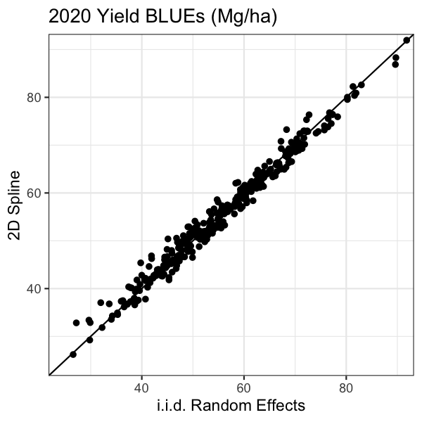

```r
compare <- merge(model1$blues,model2$blues,by=c("id","env"))
ggplot(data=compare,aes(x=BLUE.x,y=BLUE.y)) + geom_point() + xlab("i.i.d. Random Effects") + ylab("2D Spline") + theme_bw() + geom_abline(intercept=0,slope=1) + coord_cartesian(xlim=c(25,90),ylim=c(25,90)) + ggtitle("2020 Yield BLUEs (Mg/ha)")
```

With SpATS, only the generalized (entry-mean) heritability is calculated.

The above figure shows that the BLUEs are similar with the two different models. A figure showing the 2D spline and spatial distribution of residuals is also returned when SpATS is used:

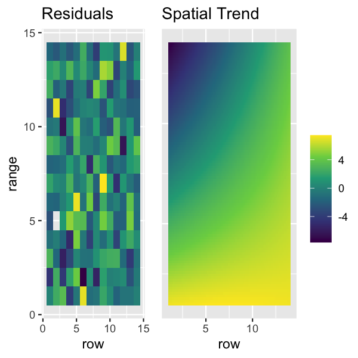

```r
model2$resid$spatial$advanced
```

Before proceeding to Stage 2, the BLUEs and variance-covariance matrices from the 2015-19 analysis and 2020 analysis need to be combined. (If other software is used for Stage 1, it can be incorporated in a similar manner.)

```r
stage1.blues <- rbind(ans1a$blues,model1$blues)
stage1.vcov <- c(ans1a$vcov,model1$vcov)
```

### Marker data

The `read_geno` function reads bi-allelic marker data as a CSV file. If you intend to run GWAS, the option `map=TRUE` indicates the first three columns of the input file are the marker name, chromosome, and position, followed by columns for the individuals. Map information is not used for genomic prediction and can be omitted by using `map=FALSE`, in which case the first column is the marker name and subsequent columns are individuals. The marker data should represent allele dosage, with numeric values between 0 and ploidy. (For compatibility with other software, the coding {-1,0,1} is also allowed for diploids.)

The potato marker data were generated using an Infinium SNP array. Most clones were genotyped with Version 3 (V3) of the array, but some were genotyped with an earlier version (V2). Data from the two different versions were combined via BLUP using the function `merge_impute` from R package polyBreedR.

```r
geno.file <- system.file("vignette_data", "geno1.csv", package = "StageWise")
geno <- read.csv(geno.file,check.names=F)
geno[1:4,1:6]
```

```
##                marker chrom position AF5392-8 AF5393-1 AF5429-3
## 1 solcap_snp_c2_51460 chr01   449027        0        1     1.03
## 2 solcap_snp_c2_36608 chr01   508800        1        0     2.00
## 3 solcap_snp_c2_36615 chr01   510745        1        0     2.03
## 4 solcap_snp_c2_36658 chr01   527068        4        3     3.00
```

```r
geno <- read_geno(filename=geno.file, ploidy=4L, map=TRUE, min.minor.allele=5,
                  dominance=T)
```

```
## Minor allele threshold = 5 genotypes
## Number of markers = 12242
## Number of genotypes = 943
```

The function `read_geno` computes genomic relationship matrices from the markers. At a minimum, the additive (G) matrix is computed. When `dominance=TRUE`, the dominance (D) matrix is also computed. These matrices and other information needed for the `Stage2` function are stored in the returned object as an S4 class.

The command `inbreeding` returns genomic inbreeding coefficients $F$, estimated from either the diagonal elements of the G matrix or the average dominance coefficient. As shown below, the two methods are very similar and have the same population mean. The negative inbreeding coefficient indicates excess heterozygosity relative to panmictic equilibrium, which may be expected when there is inbreeding depression.

```r
x <- inbreeding(geno)
head(x)
```

```
##                  F.G         F.D
## AF5392-8 -0.07650919 -0.07976518
## AF5393-1 -0.10542949 -0.10912896
## AF5429-3 -0.06456956 -0.06159264
## AF5445-2 -0.08590067 -0.08484250
## AF5450-7 -0.09444887 -0.09295317
## AF5484-3 -0.11489437 -0.11669210
```

```r
apply(x,2,mean)
```

```
##         F.G         F.D
## -0.07786684 -0.07786684
```

```r
apply(x,2,sd)
```

```
##        F.G        F.D
## 0.03414348 0.03352837
```

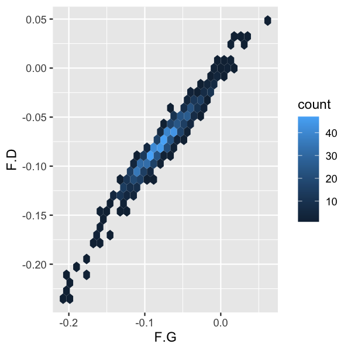

```r
ggplot(x,aes(x=F.G,y=F.D)) + geom_hex()
```

The above code shows there is relatively little variation for $F$ (sd $\approx$ 0.03), which is relevant when interpreting the results of Stage 2.

### Stage 2

The `Stage2` function uses the BLUEs from Stage 1 as the response variable, as well as their variance-covariance matrix to partition micro-environmental variation from GxE. It is also possible to run `Stage2` without the covariance of the BLUEs from Stage 1, which is necessary when there are no replicated entries within environment. In this case, use `vcov=NULL`, and covariates can be included with argument `covariates`.

The benefit of accounting for Stage 1 errors when a two-stage analysis is conducted is reflected in the lower value of AIC, which is a penalized likelihood to measure goodness-of-fit.

```r
ans2a <- Stage2(data=stage1.blues, vcov=NULL)
ans2b <- Stage2(data=stage1.blues, vcov=stage1.vcov)

data.frame(vcov=c(FALSE,TRUE), AIC=c(ans2a$aic,ans2b$aic))
```

```
##    vcov      AIC
## 1 FALSE 9634.154
## 2  TRUE 9535.647
```

```r
kable(summary(ans2a$vars))
```

|  | Variance | PVE |
| --- | --- | --- |
| env | 60.5 | NA |
| genotype | 82.0 | 0.557 |
| residual | 65.1 | 0.443 |

```r
kable(summary(ans2b$vars))
```

|  | Variance | PVE |
| --- | --- | --- |
| env | 60.0 | NA |
| genotype | 71.3 | 0.500 |
| g x env | 32.6 | 0.228 |
| Stage1.error | 38.8 | 0.272 |

Several other pieces of information are in the list output from `Stage2`. The variance components are contained in “vars” as an S4 class, which is used by the `blup_prep` function (see below). As shown above, the `summary` command returns a matrix with two columns: the first is the variance, in units of the trait; the second is the proportion of variance excluding the environment effect, which makes the result for genotype comparable to heritability (environment basis). Including the Stage1 var-cov matrix for the BLUEs enables partitioning of the residual into GxE and Stage1 error.

The above Stage 2 analysis did not include the marker data. To partition the genotype effects into additive and non-additive effects, the output from `read_geno` is included in the function call. StageWise has two ways of modeling non-additive effects. The argument non.add=“g.resid” leads to a genetic residual, with independent and identically distributed (iid) effects. When non.add=“dom” (which requires that `read_geno` was run with dominance=TRUE), the covariance of the non-additive effects follows the D matrix. To omit non-additive effects, use non.add=“none”. The AIC can be used to assess which model is better.

```r
ans2c <- Stage2(data=stage1.blues,vcov=stage1.vcov,geno=geno,
                non.add="g.resid")
ans2d <- Stage2(data=stage1.blues,vcov=stage1.vcov,geno=geno,
                non.add="dom")

data.frame(non.add=c("g.resid","dom"),AIC=c(ans2c$aic,ans2d$aic))
```

```
##   non.add      AIC
## 1 g.resid 6958.828
## 2     dom 6940.182
```

Based on the AIC values, we select the model with dominance. To compare AIC values for models with marker data to models without marker data, one needs to ensure that all individuals analyzed in Stage1 are in the marker data file. Because Stage2 excludes ungenotyped individuals from the analysis, the populations will not be the same. In this potato dataset, there are 1294 clones in the phenotype file but only 943 with marker data.

```r
kable(summary(ans2c$vars))
```

|  | Variance | PVE |
| --- | --- | --- |
| env | 51.7 | NA |
| additive | 40.4 | 0.290 |
| g.resid | 33.3 | 0.239 |
| g x env | 32.1 | 0.230 |
| Stage1.error | 33.6 | 0.241 |

```r
kable(summary(ans2d$vars))
```

|  | Variance | PVE |
| --- | --- | --- |
| env | 51.0 | NA |
| additive | 49.1 | 0.335 |
| dominance | 17.8 | 0.122 |
| heterosis | 3.8 | 0.026 |
| g x env | 42.0 | 0.287 |
| Stage1.error | 33.6 | 0.230 |

The output for the dominance model includes rows for “dominance” and “heterosis”; the former is based on the variance of a random effect with zero mean, while the latter is due to the mean ([Varona et al. 2018](https://doi.org/10.3389/fgene.2018.00078)).

The PVE for heterosis depends on two quantities: (1) baseline heterosis ($b$), which is the difference between the population at panmictic equilibrium vs. fully inbred; (2) population variation for inbreeding. As shown above, the latter is rather small. The estimate for baseline heterosis can be found in the “params” output (in trait units), or its value relative to the additive standard deviation (SDa) is calculated by the function `dominance`:

```r
ans2d$params$heterosis
```

```
##   estimate       SE
## 1 59.52934 17.83285
```

```r
dominance(ans2d$params)
```

```
##   ratio  estimate
## 1 Vd/Va 0.4374054
## 2 b/SDa 8.4843420
```

The standard error of the baseline heterosis estimate is large because of the limited variation for $F$.

### Pedigree data

Estimating additive relationships using both marker and pedigree data is often beneficial because they have complementary properties. Unlike the G matrix, the A matrix is “sparse”, meaning it has zero covariance between unrelated individuals. However, the A matrix does not account for segregation within biparental families or capture LD between founders. The G and A matrices can be combined into an “H” matrix, which also allows ungenotyped individuals to be included in the relationship matrix ([Legarra et al. 2009](https://doi.org/10.3168/jds.2009-2061); [Christensen and Lund 2010](https://doi.org/10.1186/1297-9686-42-2)). (The inclusion of ungenotyped individuals is only available with the genetic residual model.)

To illustrate this feature, a three-column pedigree file for the potato population is included with the package. When combining the G and A matrices, their relative weights must be specified using the argument `w` in `read_geno`, such that H = (1-w)G + wA.

```r
ped.file <- system.file("vignette_data", "ped.csv", package = "StageWise")
ped <- read.csv(ped.file)
geno2 <- read_geno(geno.file,ploidy=4,map=TRUE,ped=ped,w=0.1,dominance = TRUE)
```

```
## Minor allele threshold = 5 genotypes
## Number of markers = 12242
## Number of genotypes = 943
```

```r
ans2e <- Stage2(data=stage1.blues,vcov=stage1.vcov,geno=geno2,non.add="dom")
ans2e$aic
```

```
## [1] 6935.89
```

```r
kable(summary(ans2e$vars))
```

|  | Variance | PVE |
| --- | --- | --- |
| env | 51.3 | NA |
| additive | 56.9 | 0.385 |
| dominance | 13.8 | 0.093 |
| heterosis | 3.5 | 0.024 |
| g x env | 40.1 | 0.271 |
| Stage1.error | 33.6 | 0.227 |

The above result shows that blending G and A at w=0.1 slightly reduced the AIC and shifted variance from the non-additive to additive component. One way to select the blending parameter is based on AIC. When a vector of w values is provided to `read_geno`, the function returns a list output corresponding to those values. For numerical conditioning, a minimum threshold of 1e-5 is used for w.

```r
w.vec <- c(1e-5, seq(0.2,0.8,by=0.2))
geno <- read_geno(geno.file,ploidy=4,map=TRUE,ped=ped,w=w.vec,dominance=TRUE)
```

```
## Minor allele threshold = 5 genotypes
## Number of markers = 12242
## Number of genotypes = 943
```

```r
result <- data.frame(w=w.vec, aic=numeric(5), h2=numeric(5))
ans2 <- vector("list",5)
for (i in 1:5) {
  ans2[[i]] <- Stage2(data=stage1.blues,vcov=stage1.vcov,geno=geno[[i]],non.add="dom")
  result$aic[i] <- ans2[[i]]$aic
  result$h2[i] <- summary(ans2[[i]]$vars)[2,2]
}
```

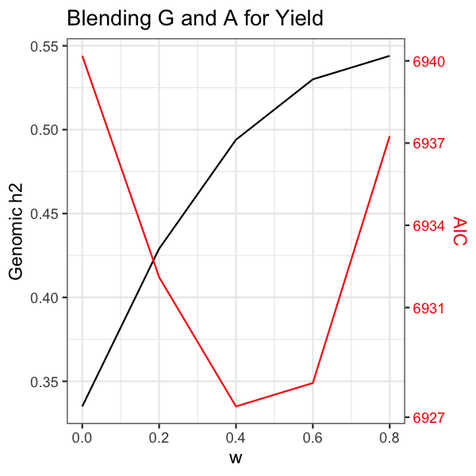

```r
axis.scaling <- diff(range(result$h2))/diff(range(result$aic))
result$y2 <- (result$aic-min(result$aic))*axis.scaling + min(result$h2)
y2lab <- round(seq(min(result$aic),max(result$aic),length.out=5))
y2axis <- y2lab-min(result$aic) + min(result$h2)/axis.scaling

ggplot(result) + geom_line(mapping=aes(x=w,y=h2)) + geom_line(mapping=aes(x=w,y=y2),colour="red") + scale_y_continuous(name="Genomic h2",sec.axis=sec_axis(trans~./axis.scaling,name="AIC",breaks=y2axis,labels=y2lab)) + theme_bw() +
  theme(axis.text.y.right=element_text(colour="red"),axis.title.y.right=element_text(colour="red")) + ggtitle("Blending G and A for Yield")
```

Based on the above figure, the blending parameter w=0.4 is chosen, at which there is no longer much dominance variance. The optimal value for w will not be the same for all traits.

```r
w.vec[3]
```

```
## [1] 0.4
```

```r
genoH <- geno[[3]]
ans2H <- ans2[[3]]
kable(summary(ans2H$vars))
```

|  | Variance | PVE |
| --- | --- | --- |
| env | 51.5 | NA |
| additive | 74.2 | 0.494 |
| dominance | 5.0 | 0.033 |
| heterosis | 2.9 | 0.019 |
| g x env | 34.5 | 0.230 |
| Stage1.error | 33.6 | 0.224 |

To include ungenotyped individuals in the H matrix, put a fourth column in the pedigree data frame with binary (0/1) values to indicate which individuals should be included.

### BLUP Reliability

The calculation of BLUPs is split into two functions: `blup_prep` and `blup`. The computationally intensive steps occur in `blup_prep`, which combines the phenotype and genotype information used in `Stage2` with the variance component estimates to estimate the var-cov matrix of the predicted random effects. The `blup` command extracts the appropriate linear combination of predictions based on the argument “what”, which has 5 possible values:

- AV = additive values
- BV = breeding values
- GV = genotypic values
- AM = additive marker effects
- DM = dominance marker effects

The “values” are properties of individuals, as opposed to markers. Breeding values should be used for parent selection, while genotypic values should be used for clone selection. For diploids, the AV and BV are equivalent. For polyploids, if the dominance model was used, the BV includes a portion of the dominance. GV is the sum of additive and non-additive values. When predicting values, the software also returns the predicted reliability r2, which is the squared correlation between the true and predicted values (assuming the model is correct).

The following code illustrates the prediction of genotypic values:

```r
prep1 <- blup_prep(data=stage1.blues,
              vcov=stage1.vcov,
              geno=genoH,
              vars=ans2H$vars)
GV1 <- blup(prep1, geno=genoH, what="GV")
kable(head(GV1),digits=2)
```

| id | value | r2 |
| --- | --- | --- |
| AF5392-8 | 54.39 | 0.56 |
| AF5393-1 | 54.95 | 0.70 |
| AF5429-3 | 62.97 | 0.74 |
| AF5445-2 | 72.00 | 0.70 |
| AF5450-7 | 67.85 | 0.70 |
| AF5484-3 | 58.92 | 0.78 |

The figure below illustrates how the reliability of genotypic value predictions is typically higher when using marker data because it improves estimation of the additive component.

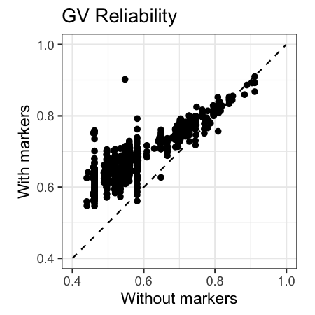

```r
#predict genotypic values without marker data
prep2 <- blup_prep(data=stage1.blues,
              vcov=stage1.vcov,
              vars=ans2b$vars)
GV2 <- blup(prep2, what="GV")

plot.data <- merge(GV2,GV1,by="id")
ggplot(plot.data,aes(x=r2.x,y=r2.y)) + geom_point() + ggtitle("GV Reliability") + theme_bw() +
  xlab("Without markers") + ylab("With markers") + coord_fixed(ratio=1) + ylim(0.4,1) + xlim(0.4,1) + geom_line(data=data.frame(x=c(0.4,1),y=c(0.4,1)),mapping=aes(x=x,y=y),linetype=2)
```

The `blup_prep` function allows for masking the phenotypes of some individuals before making the predictions, which allows for cross-validation. All else being equal, predictions for individuals without phenotypes, which is called marker-based selection, have lower reliability than predictions for individuals with phenotypes, which is called marker-assisted selection. To illustrate, we will mask the phenotypes for the most recent cohort of breeding lines in the dataset (which have names beginning with “W17”) and compare with the previous prediction.

```r
id <- stage1.blues$id
mask <- data.frame(id=unique(id[substr(id,1,3)=="W17"]))
head(mask)
```

```
##          id
## 1  W17037-1
## 2 W17037-10
## 3 W17037-11
## 4 W17037-12
## 5 W17037-13
## 6 W17037-15
```

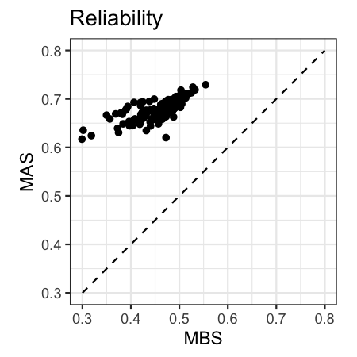

```r
prep3 <- blup_prep(data=stage1.blues,
              vcov=stage1.vcov,
              geno=genoH,
              vars=ans2H$vars,
              mask=mask)
GV3 <- blup(prep3, geno=genoH, what="GV")

plot.data <- merge(GV3, GV1, by="id")
plot.data <- plot.data[plot.data$id %in% mask$id,]

ggplot(plot.data,aes(x=r2.x,y=r2.y)) + geom_point() + theme_bw() + ggtitle("Reliability") +
  xlab("MBS") + ylab("MAS") + coord_fixed(ratio=1) + geom_line(data=data.frame(x=c(0.3,0.8),y=c(0.3,0.8)),mapping=aes(x=x,y=y),linetype=2)
```

Using the `mask` argument, one can also specify that individuals are masked only in some environments, which is useful for assessing the accuracy of prediction into new environments based on phenotypes in other environments. This idea is revisited in Vignette 2.

### Marker effects and GWAS

Using what=“AM” or “DM” leads to the prediction of additive or dominance marker effects, respectively, in `blup`. This can be a convenient way to save the results of a training set analysis to predict future individuals. Multiplying the additive marker effects by the matrix of (centered) marker dosages to obtain additive values is equivalent (up to a constant) to directly predicting the additive values using what=“AV”, provided there has been no blending with the pedigree relationship matrix:

```r
#w = 0
prep <- blup_prep(data=stage1.blues,vcov=stage1.vcov,geno=geno[[1]],vars=ans2[[1]]$vars)
marker.effects <- blup(data=prep, geno=geno[[1]], what="AM")
head(marker.effects)
```

```
##                marker chrom position       effect
## 1 solcap_snp_c2_51460 chr01   449027 -0.008699362
## 2 solcap_snp_c2_36608 chr01   508800  0.023544993
## 3 solcap_snp_c2_36615 chr01   510745  0.003188104
## 4 solcap_snp_c2_36658 chr01   527068  0.044723421
## 5 solcap_snp_c1_10930 chr01   566972  0.023206037
## 6       PotVar0120126 chr01   603013  0.001992423
```

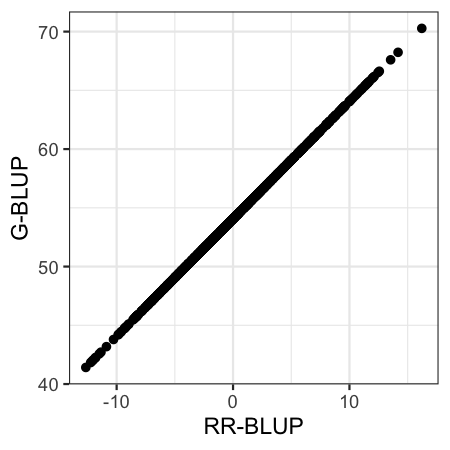

```r
AV1 <- predict(geno[[1]], marker.effects)

#compare with G-BLUP
AV2 <- blup(data=prep, geno=geno[[1]], what="AV")
plot.data <- merge(AV1, AV2, by="id")
ggplot(plot.data,aes(x=value.x,y=value.y)) + geom_point() + xlab("RR-BLUP") + ylab("G-BLUP") + theme_bw()
```

This equivalency also holds for genotypic values (A + D):

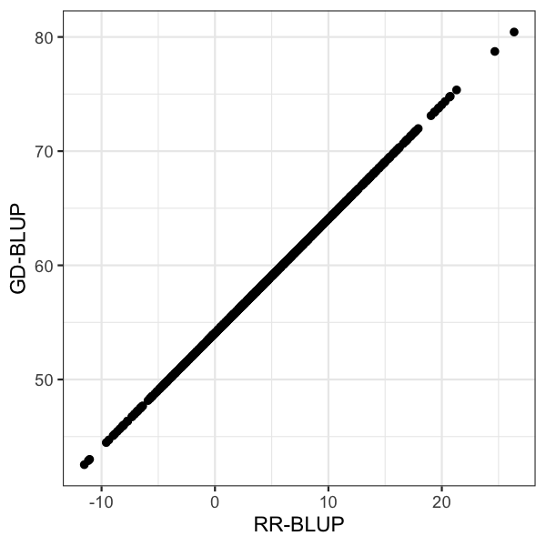

```r
DM <- blup(data=prep, geno=geno[[1]], what="DM")
DV1 <- predict(geno[[1]], DM)
GEGV1 <- data.frame(id=AV1$id, value=AV1$value + DV1$value)

GEGV2 <- blup(data=prep, geno=geno[[1]], what="GV")
plot.data <- merge(GEGV1,GEGV2,by="id")

ggplot(plot.data,aes(x=value.x,y=value.y)) + geom_point() + xlab("RR-BLUP") + ylab("GD-BLUP") + theme_bw()
```

The marker effects can be standardized to compute GWAS -log10(p) scores that are equivalent to the traditional fixed effect method ([Duarte et al. (2014)](http://www.biomedcentral.com/1471-2105/15/246); [Bernal Rubio et al. 2016](https://doi.org/10.1111/age.12378)). This calculation is easily parallelized, and the argument `gwas.ncore` specifies how many cores to use (the default is 0, which skips computing the GWAS scores). The `gwas_threshold` command computes the -log10(p) threshold for QTL discovery based on an effective number of markers ([Moskvina and Schmidt, 2008](https://doi.org/10.1002/gepi.20331)), and `manhattan_plot` displays the result. For yield there were no significant QTL, so results for the vine maturity trait are shown instead.

```r
effects <- data.frame(name="block",fixed=FALSE,factor=TRUE)
ans1vm <- Stage1(filename=pheno1a.file,traits="vine.maturity",
                effects=effects,solver="asreml")
ans2vm <- Stage2(data=ans1vm$blues, vcov=ans1vm$vcov, geno=geno[[1]],
                 non.add="dom")

prep <- blup_prep(ans1vm$blues, ans1vm$vcov, geno[[1]], ans2vm$vars)
gwas.ans <- blup(prep, geno[[1]], what="AM", gwas.ncore=2)
head(gwas.ans)
```

```
##                marker chrom position        effect     score
## 1 solcap_snp_c2_51460 chr01   449027 -0.0009276395 0.2699447
## 2 solcap_snp_c2_36608 chr01   508800  0.0030442837 0.7265478
## 3 solcap_snp_c2_36615 chr01   510745  0.0010404326 0.3693143
## 4 solcap_snp_c2_36658 chr01   527068  0.0022755583 0.5325289
## 5 solcap_snp_c1_10930 chr01   566972  0.0013878767 0.2930203
## 6       PotVar0120126 chr01   603013  0.0023887891 0.5896128
```

```r
gwas_threshold(geno[[1]], alpha=0.05, n.core=2)
```

```
## [1] 5.103417
```

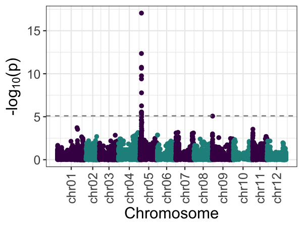

```r
manhattan_plot(gwas.ans, thresh=5.1, rotate.label=TRUE)
```

The GWAS peak on chr05 is near the gene *CDF1*, which is known to have a large effect on potato maturity [(Kloosterman et al. 2013)](https://doi.org/10.1038/nature11912). The following code extracts the most significant marker for the large QTL on chr05 and passes it to `Stage2` as a fixed effect.

```r
k <- which.max(gwas.ans$score)
gwas.ans[k,]
```

```
##                   marker chrom position      effect    score
## 5334 solcap_snp_c2_22964 chr05  4422417 -0.01642851 17.05289
```

```r
ans2vm.1 <- Stage2(data=ans1vm$blues,
               vcov=ans1vm$vcov,
               geno=geno[[1]],
               fix.eff.marker="solcap_snp_c2_22964",
               non.add="g.resid")

# Fixed effect for the marker
ans2vm.1$params$marker
```

```
##                marker   estimate         SE
## 1 solcap_snp_c2_22964 -0.7764807 0.08692611
```

```r
# Proportion of variance
kable(summary(ans2vm.1$vars))
```

|  | Variance | PVE |
| --- | --- | --- |
| env | 0.485 | NA |
| fixed.marker | 0.313 | 0.123 |
| additive | 0.596 | 0.235 |
| g.resid | 0.445 | 0.176 |
| g x env | 0.297 | 0.117 |
| Stage1.error | 0.884 | 0.349 |

The fixed effect estimate of -0.78 for solcap_snp_c2_22964 implies that, on average, each additional copy of the alternate allele reduced vine maturity by 0.78 (on a 1-9 visual scale). According to the proportion of variance table, the marker accounted for 0.123/(0.123 + 0.235) = 34% of the breeding value.